# The gramar of graphics in R: ggplot2

Matthias Templ  
R Summer School, Vorau 2017

### Why ggplot2?

- consistent and systematic approach to generate graphics
- based on the book *Grammar of Graphics* by Wilkinson (data, aesthetic mapping, geoms, stats, scales, facets, themes)
- it does many things for you (optimal margins, faceting, legends, …)
- customizable. allows to define own themes (e.g. for cooperative designs in companies)
- But: slow and it is not as easy to learn

### Example of a plot (1) - graphics

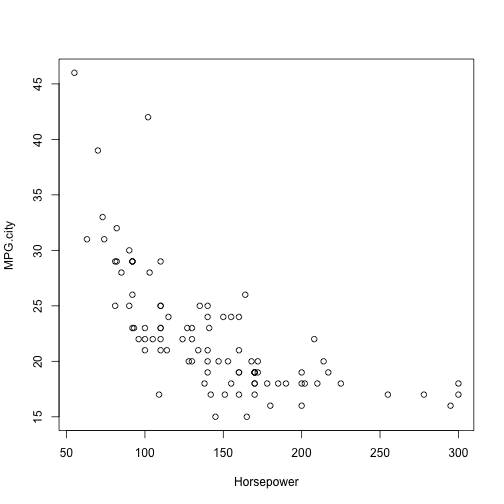

```r
data("Cars93", package="MASS")
plot(MPG.city ~ Horsepower, data=Cars93)
```

### Example of a plot (2) - ggplot2

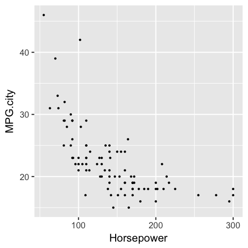

```r
require("ggplot2")
ggplot(Cars93, aes(x=Horsepower, y=MPG.city)) + geom_point()
```

### Example of a plot (3) - ggvis

```r
require("ggvis")
Cars93 %>% ggvis(x = ~Horsepower, y = ~MPG.city) %>% layer_points()
```

[figure not shown]

### Output from graphics and ggplot2 (1)

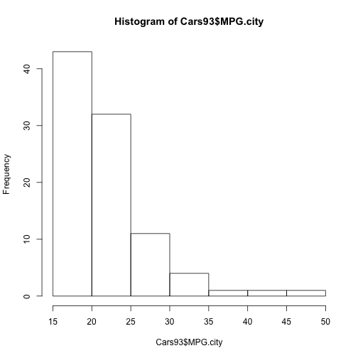

```r
hist(Cars93$MPG.city)
```

### Output from graphics and ggplot2 (2)

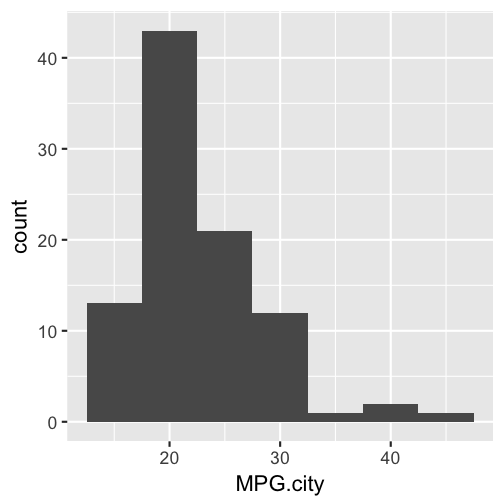

```r
ggplot(Cars93, aes(x=MPG.city))+
  geom_histogram(binwidth=5)
```

### Output from graphics and ggplot2 (3)

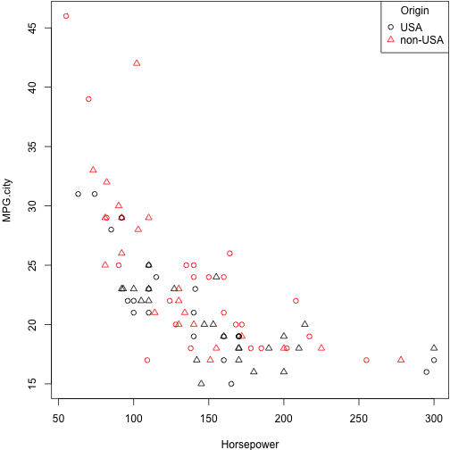

```r
par(mar=c(4,4,.1,.1))
plot(MPG.city ~ Horsepower, data=Cars93,
     col=Cars93$Origin, pch=c(1,2))
legend("topright", c("USA", "non-USA"),
     title="Origin", pch=c(1,2),
     col=c("black", "red"))
```

### Output from graphics and ggplot2 (4)

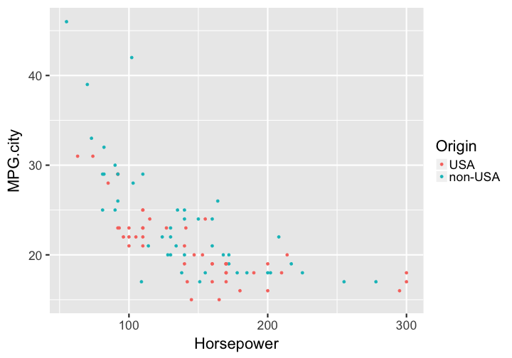

```r
ggplot(Cars93, aes(x=Horsepower, y=MPG.city, color=Origin)) + geom_point()
```

### Output from graphics and ggplot2 (5)

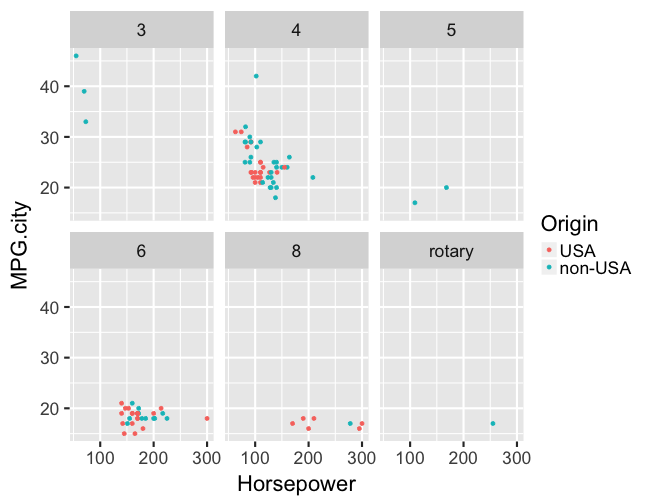

```r
ggplot(Cars93, aes(x=Horsepower, y=MPG.city, color=Origin)) + geom_point() + facet_wrap(~Cylinders)
```

### Grammar of graphics with ggplot2

- parts of a plot defined independently
- the anatomy of a plot:
  - data
  - **aesthetic mapping**: describe how **variables** in the data are mapped to visual properties (aesthetics) of geometric objects
  - **assignment**: values are mapped to visual properties
  - geometric objects (geom's, aesthetic will be mapped to geometric objects)
  - statistical transformation
  - scales
  - coordinate system
  - position adjustments
  - faceting

### aesthetic

- aesthetic means “something you can see”
  - color
  - fill (color)
  - shape (of points)
  - linetype
  - size
  - …

### aesthetic mapping

- aesthetic mapping to geometric objects with function **aes()**

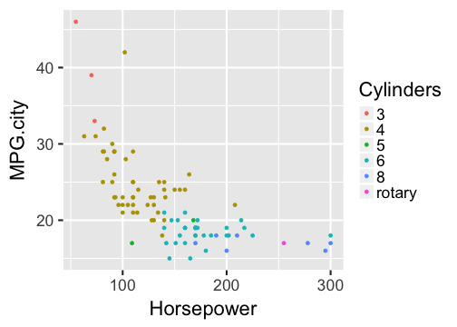

```r
ggplot(Cars93, aes(x = Horsepower, y = MPG.city)) + geom_point(aes(color = Cylinders))
```

### geometric objects (geom's)

- aesthetic mapping to geometric objects with function **aes()**
- add geom using **+**
- each type of geom only accepts a subset of aesthetics (e.g. setting **shape** in **aes()** and makes no sense when mapped to **geom_bar**)

### more than one geom (1)

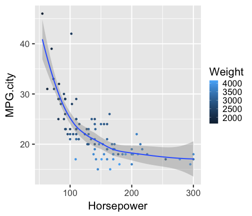

```r
g1 <- ggplot(Cars93, aes(x=Horsepower, y=MPG.city))
g2 <- g1 + geom_point(aes(color=Weight)) + geom_smooth()
g2
```

### more than one geom (2)

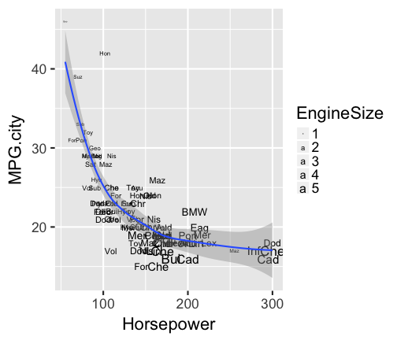

```r
g1 + geom_text(aes(label=substr(Manufacturer,1,3), size=EngineSize)) + geom_smooth()
```

### more than one geom (3)

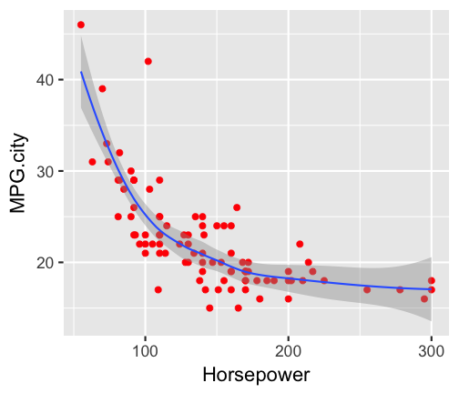

```r
## value outside aes() -- assignment
g1 + geom_point(color="red", size=3) + geom_smooth()
```

### more than one geom (4)

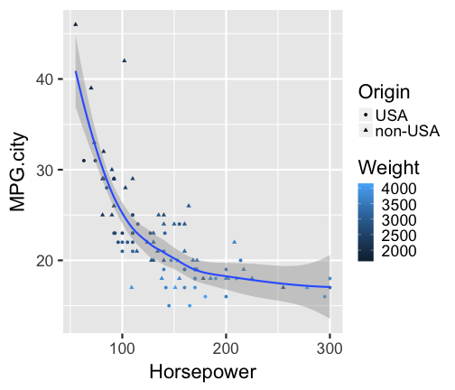

```r
## variable inside aes() -- aesthetic mapping d
g1 + geom_point(aes(color=Weight, shape=Origin)) + geom_smooth()
```

### layer defaults (1)

- each block of a ggplot2 can be defined with parameters
- to make life easy: standard default parameter values
- default values for geoms:

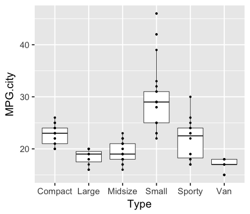

```r
g <- ggplot(Cars93, aes(x = Type, y = MPG.city))
g + geom_boxplot() + geom_point()
```

### layer defaults (2)

- default values for statistics:

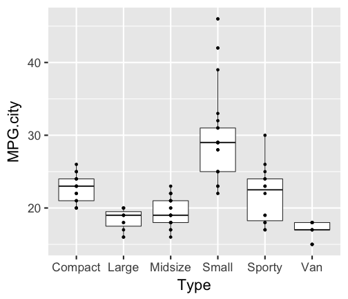

```r
g <- ggplot(Cars93, aes(x = Type, y = MPG.city))
g + stat_boxplot() + geom_point()
```

### stats

all (geoms) associated with statistical transformations - stats

- the easiest one: the identity
- for some geom's, the data are modified, e.g. geom_boxplot
- specific paramters for specific plots, e.g. *binwidth*

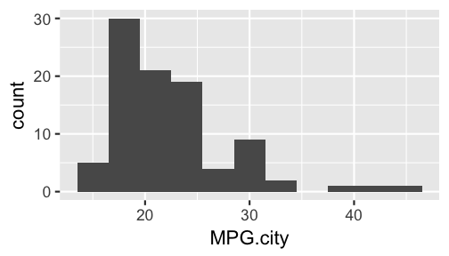

```r
ggplot(Cars93, aes(x = MPG.city)) + geom_histogram(binwidth=3)
```

### Example, flexibilty

```r
g <- ggplot(Cars93, aes(x = MPG.city, y = Horsepower))
```

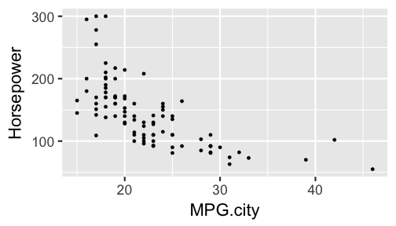

```r
g + geom_point()
```

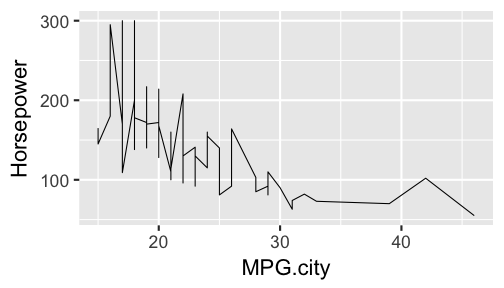

```r
g + geom_line()
```

### Example, grouping

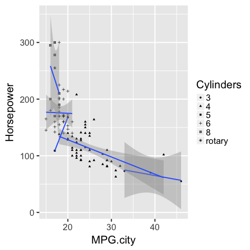

```r
ggplot(Cars93, aes(MPG.city, Horsepower, shape = Cylinders))+
  geom_point() + stat_smooth(method = "lm")
```

### Scales: aesthetics for variables

scales can define:

- color and fill (color)
- size
- shape
- linetype Scales are defined and modified by using the function **scale**

### Example: scales

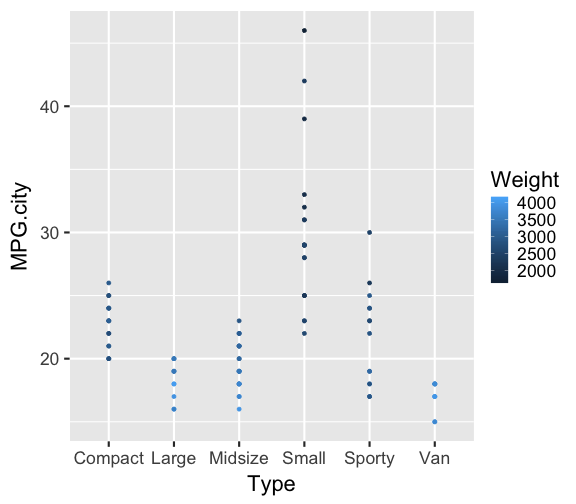

```r
g <- ggplot(Cars93, aes(x = Type, y = MPG.city))
g <- g + geom_point(aes(color = Weight))
g
```

### Example: scales

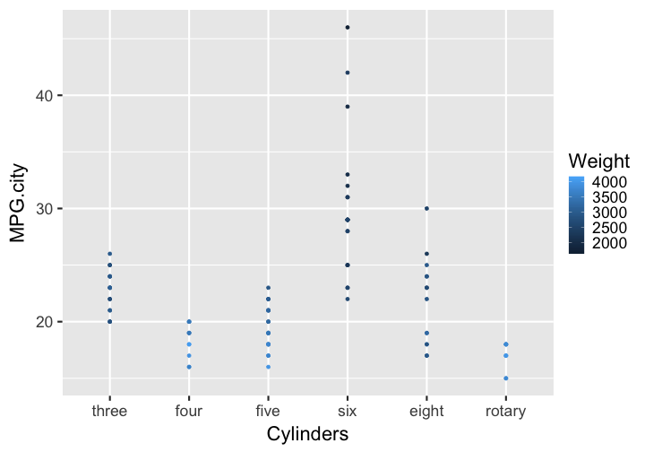

```r
g <- g + scale_x_discrete("Cylinders", labels = c("three","four","five","six","eight","rotary"))
g
```

### Example: scales

```r
m <- max(Cars93$MPG.city)
g <- g + scale_y_continuous(breaks=c(10,20,30,m), labels=c("ten (10)", "twenty (20)", "thirty (30)", paste("max (",m,")"))); g
```

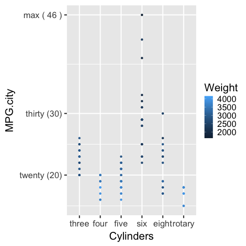

### Overview scales

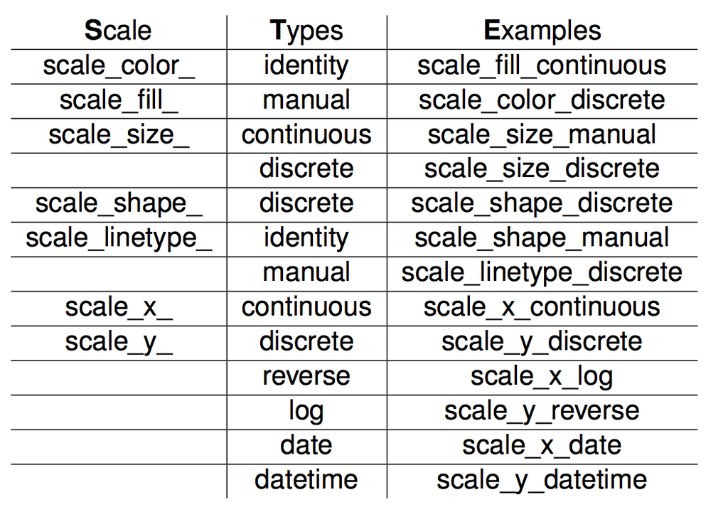

### faceting

A “standardized”“ graphic for each group in the data.

- for one grouping variable: **facet_wrap()**
- for two grouping variables: **facet_grid()**

### What's happend on Titanic?

```r
data(td)
str(td)
```

```
'data.frame':   59 obs. of  4 variables:
 $ pclass: int  1 1 1 1 1 1 1 1 1 1 ...
 $ age.g : int  1 1 2 2 3 3 4 4 5 5 ...
 $ sex   : Factor w/ 2 levels "female","male": 1 2 1 2 1 2 1 2 1 2 ...
 $ ps    : num  0 1 1 1 1 ...
```

```r
head(td,12)
```

```
   pclass age.g    sex        ps
1       1     1 female 0.0000000
2       1     1   male 1.0000000
3       1     2 female 1.0000000
4       1     2   male 1.0000000
5       1     3 female 1.0000000
6       1     3   male 0.2857143
7       1     4 female 0.9473684
8       1     4   male 0.4615385
9       1     5 female 0.9666667
10      1     5   male 0.4074074
11      1     6 female 1.0000000
12      1     6   male 0.2812500
```

```r
## note: ps = ratio of people survived
```

### What's happend on Titanic?

Scatterplot, two clusters are visible

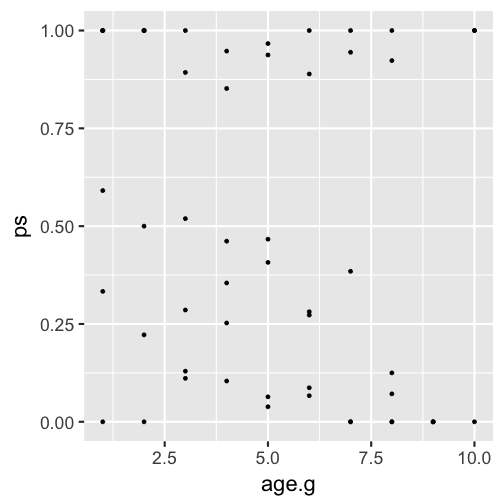

```r
tdg <- ggplot(td, aes(x = age.g, y = ps))
tdg + geom_point()
```

### What's happend on Titanic?

what we already learned, aesthetic mapping…

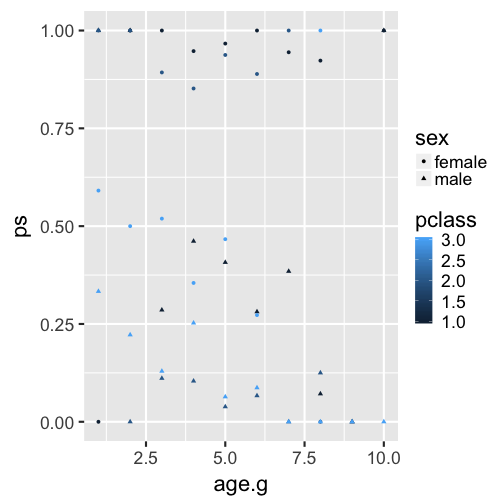

```r
tdg + geom_point(aes(color = pclass, shape = sex))
```

### What's happend on Titanic?

faceting…

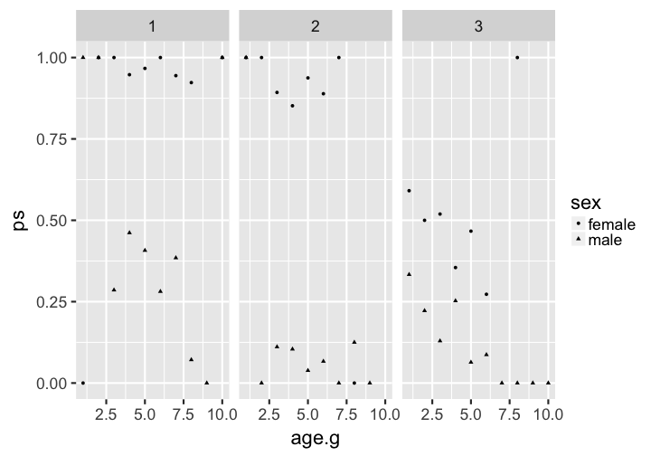

```r
tdg + geom_point(aes(shape = sex)) + facet_wrap( ~ pclass)
```

### What's happend on Titanic?

faceting… with two grouping variables

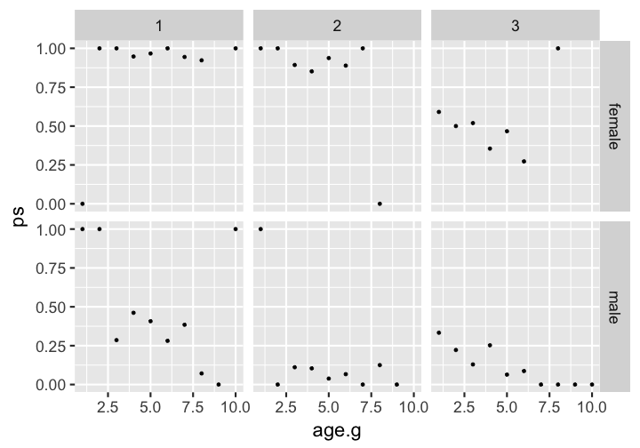

```r
tdg <- tdg + geom_point() + facet_grid(sex ~ pclass)
tdg
```

### Example: themes

themes for cooperative design. Two themes which comes with ggplot2:

- **theme_gray()** - default
- **theme_bw()**

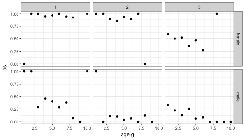

```r
tdg + theme_bw()
```

### Example: themes

In the web you can found a number of user-generated themes

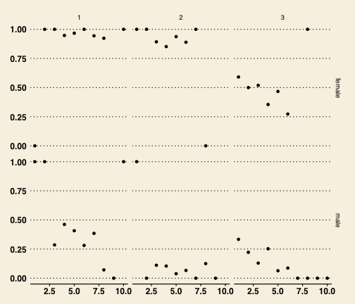

```r
library(ggthemes)
tdg + theme_wsj()
```

### Example: themes

type **theme_gray()** to see a list with options. Using function **theme()** you can modify them.

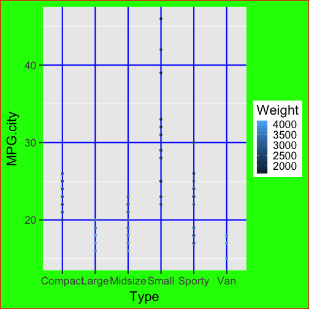

```r
gg <- ggplot(Cars93, aes(x = Type, y = MPG.city))
gg <- gg + geom_point(aes(color = Weight))
gg + theme(plot.background = element_rect(fill = 'green', colour = 'red')) +  theme(panel.grid.major = element_line(colour = "blue"))
```

### Example: themes

Create your own theme!

```r
theme_new <- function(base_size = 12, base_family = "Helvetica"){
  theme_bw(base_size = base_size, base_family = base_family) %+replace%
    theme(
      axis.title = element_text(size = 16),
      legend.key=element_rect(colour=NA, fill =NA),
      panel.grid = element_blank(),
      panel.border = element_rect(fill = NA, colour = "blue", size=2),
      panel.background = element_rect(fill = "red", colour = "black"),
      strip.background = element_rect(fill = NA)
      )
}
```

### Example: themes

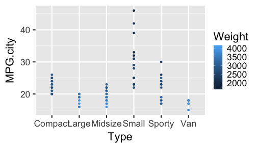

```r
gg
```

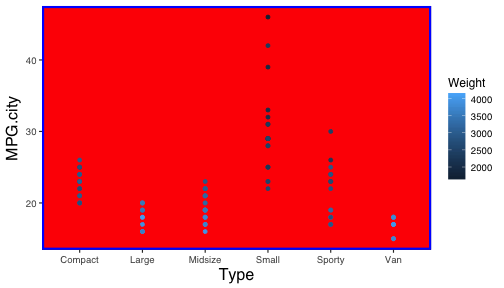

```r
gg + theme_new()
```

### New features in ggplot2

- geom_blank for plot with no layers
- geom_count for overlaying points
- subtitles and captions
- improved faceting and axis notations
- improved legend style
- imroved barcharts

### Additional features

- package ggthemes: more themes
- package gplots: more features, e.g. on regression diagnostic plots, Venn diagrams, …
- ggtern: ternary diagrams
- ggfortify: biplots, …
- ggiraph https://www.ggplot2-exts.org/ggiraph.html
- **package ggmap**: maps (https://journal.r-project.org/archive/2013-1/kahle-wickham.pdf)
- ggraph, ggforce (new stats and geoms), gganimate
- **ggplotly** (https://plot.ly/r/)
- further extensions: http://www.ggplot2-exts.org/gallery/